# Consumer Credit Purpose Overview

# Summary

This is an exploratory analysis on the purposes our users give when applying to a consumer credit, either directly with N26, or with one of our external providers (Auxmoney and Younited). After looking into when the purposes were first created, we decided to only consider drafts created between 2018-01-01 and 2020-08-31.

Here are the main take-aways:

- The consumer credit purposes order can change greatly depending on whether we look into drafts or offers, whether these offers are disbursed, and the provider of these offers (the list of purposes depends on the country of application).
- Generally, "car" related purposes are usually one of the most picked across the board, and when looking into disbursed offers, the purposes "Overdraft" and "Home Improvement" also tend to be amongst the most chosen ones.
- 79.2% percent of the users that have more than one credit offer use only one purpose for all their offers.
- Moving forward, we should investigate if there is any correlation between these purposes and credit scores/ write-off rates.

# Purpose per Draft

When looking into the volume of Credit Purposes per draft in all time we can see that the purpose "CAR", "APPLIANCES" and "USED_CAR" are the most common ones, corresponding to 43% of all drafts.

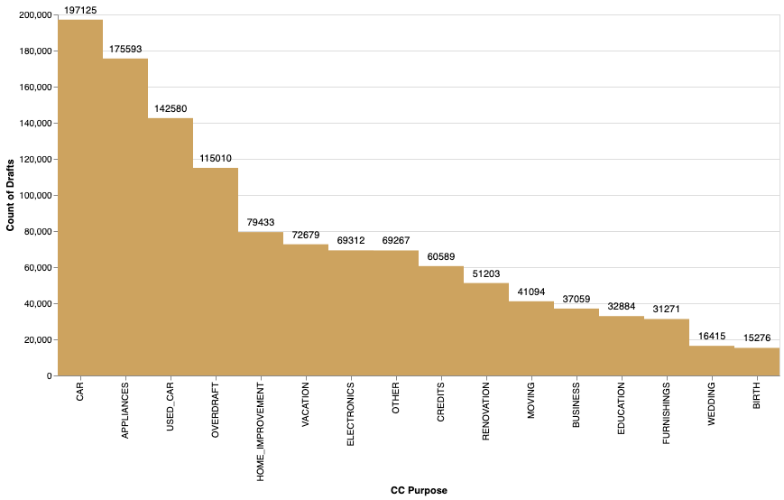

## Top 3 purposes over time

("CAR", "APPLIANCES" and "USED_CAR")

By comparing these top 3 purposes over time, we can see that the drafts with the purpose "CAR" have an unusual amount of drafts in February 2017. Also, we can see that 7 out of the 16 purposes were only implemented by the end of 2017. Therefore, the results following this section will only consider data between Jan 2018 and Aug 2020.

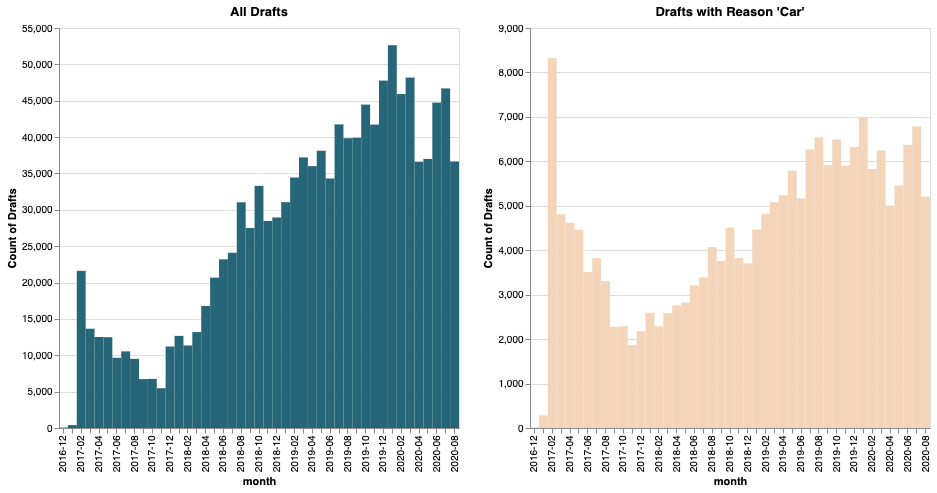

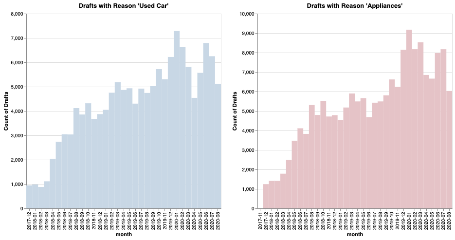

|  | purpose_name | min_created_tstamp |
| --- | --- | --- |
| 0 | HOME_IMPROVEMENT | 2016-12-16 |
| 1 | CAR | 2016-12-16 |
| 2 | OVERDRAFT | 2016-12-16 |
| 3 | VACATION | 2016-12-17 |
| 4 | OTHER | 2016-12-17 |
| 5 | ELECTRONICS | 2016-12-18 |
| 6 | BUSINESS | 2016-12-22 |
| 7 | EDUCATION | 2016-12-22 |
| 8 | CREDITS | 2016-12-23 |
| 9 | APPLIANCES | 2017-11-30 |
| 10 | WEDDING | 2017-12-04 |
| 11 | FURNISHINGS | 2017-12-04 |
| 12 | USED_CAR | 2017-12-12 |
| 13 | RENOVATION | 2017-12-12 |
| 14 | MOVING | 2017-12-12 |
| 15 | BIRTH | 2017-12-12 |

## Purposes per Draft

(Jan 2018 - Aug 2020)

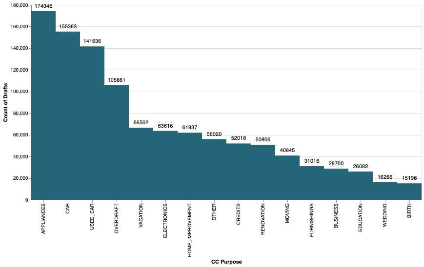

# Purpose per [disbursed] offer

As for all offers and disbursed offers, we can find a very different purposes pattern than when comparing with drafts. Namely, purposes like "APPLIANCES", that were between the most common purposes for drafts, are now showing as some of the least common in disbursed offers.

Also, when looking into disbursed offers, the purposes "Overdraft" and "Home Improvement" tend to be amongst the most chosen ones.

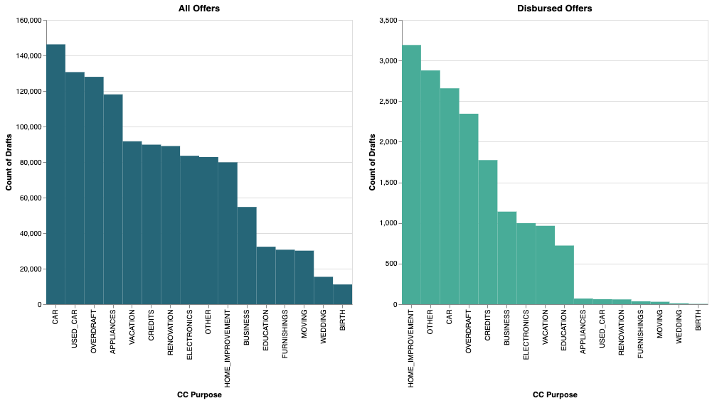

## All Offer Purposes per Provider

It seems these differences above happened due to the fact that the list of purposes depends on the country of application, and therefore not all purposes are used by all providers. This is especially visible with the purposes that are exclusive to the provider "YOUNITED”, since their offer conversion rate (from all offers to disbursed offers) is only 0.08%.

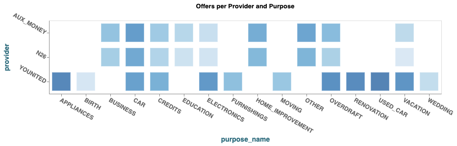

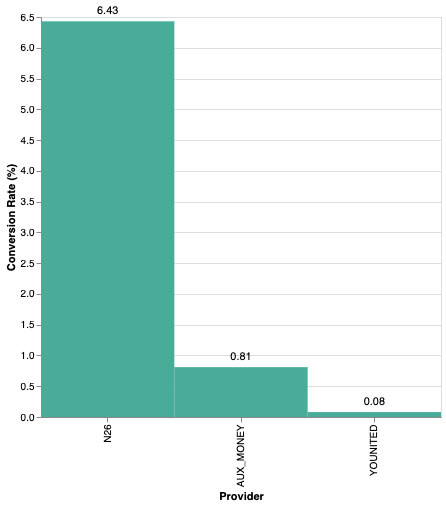

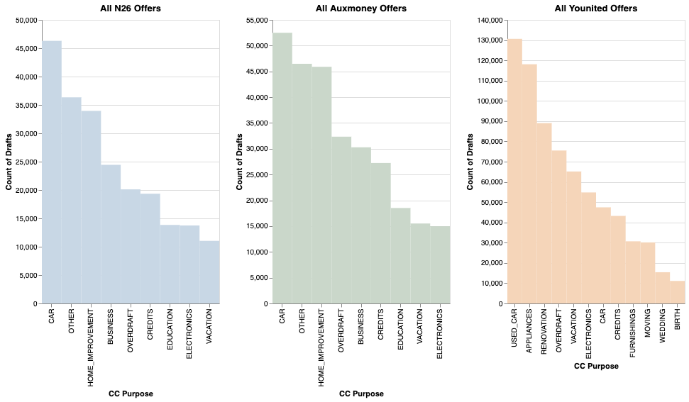

## Disbursed Purposes per Provider

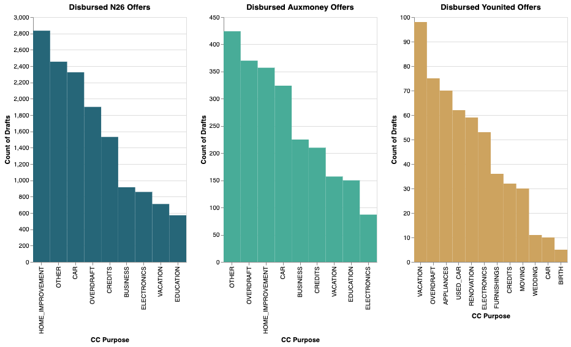

# Number of Offer Purposes per User

Finally, when looking into how many different purposes our users give in all their offers (filtered for users that have more offers), we can see that most users (79.2%) use only one purpose for all their offers.

|  | number_of_purposes | user_created | percentage |
| --- | --- | --- | --- |
| 0 | 1 | 57288 | 79.2 |
| 1 | 2 | 11347 | 15.7 |
| 2 | 3 | 2745 | 3.8 |
| 3 | 4 | 710 | 1.0 |
| 4 | 5 | 200 | 0.3 |
| 5 | 6 | 67 | 0.1 |
| 6 | 7 | 10 | 0.0 |
| 7 | 8 | 3 | 0.0 |

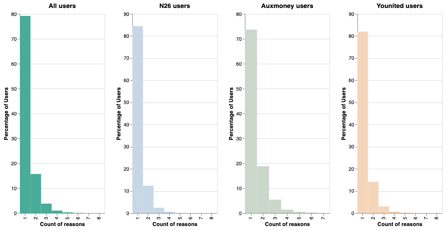

# Future Recommendations

Since this was an exploratory analysis into this topic, the main recommendations here are to continue on exploring this topic, specifically in trying to see if there is any correlation between these purposes and credit scores/ write-off rates. More specifically, we can look into:

- Average SCHUFA score per purpose (N26 and Auxmoney only)
- Percentage of write-offs per purpose
- Credit volume per purpose